# Triangle Tests and Hypothesis Tests

TEMBA Statistics 2026

## Mexican Coke and regular Coke

Can we identify Mexican Coke in a blind tasting?

Each group of four gets **one bottle of Mexican Coke and two cans of regular Coke**.

One person administers the test to the other three. Each taster gets three cups: one with Mexican Coke and two with regular Coke.

## Running the test

1. While the tasters look away, mark the bottom of each set’s Mexican Coke cup. Pour Mexican Coke into it and regular Coke into the other two cups.
2. Shuffle each set separately. Keep the bottom markings hidden.
3. Each taster privately records which cup seems different, even if guessing.
4. After all three have recorded a choice, check the bottoms and count the correct picks.

## Variation under guessing

If 42 people guess independently, we expect **14 correct picks on average**.

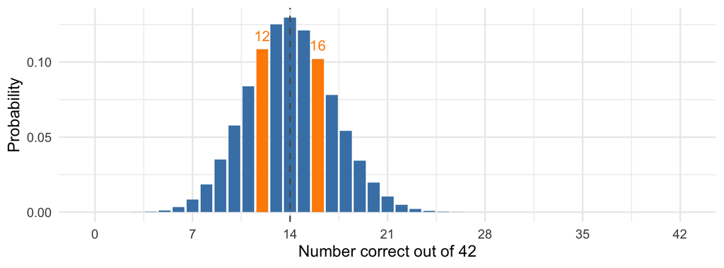

Results such as 12 or 16 correct are consistent with guessing.

## Null and alternative hypotheses

Let $p$ be the probability of a correct pick under these tasting conditions.

$$H_0:p=1/3,\qquad H_A:p>1/3.$$

Under the **null hypothesis**, the chance of a correct pick is 1/3, the rate from random guessing. The alternative says accuracy is higher.

We will use a significance level of $\alpha=0.05$.

## The test statistic

Use the sample proportion correct. Larger values provide stronger evidence against guessing.

$$\hat p=\frac{\text{number correct}}{\text{number of tasters}}.$$

Enter the class counts.

## Panel size and precision

Two illustrative panels give the same sample proportion:

| Tasters | Correct | Sample proportion | Estimated SE |
| --- | --- | --- | --- |
| 4 | 2 | 0.50 | 0.250 |
| 42 | 21 | 0.50 | 0.077 |

The same departure from $1/3$ is more unusual in the larger panel.

## The t-statistic

$$SE\approx\sqrt{\frac{\hat p(1-\hat p)}{n}},\qquad
t=\frac{\hat p-1/3}{SE}.$$

The statistic counts standard errors between our estimate and the guessing value.

Enter the class counts on the test-statistic slide.

## The p-value

Under $H_0$, $T\approx N(0,1)$ when the normal approximation is adequate. The one-sided **p-value** is $\Pr(T\geq t\mid H_0)$.

Enter the class counts to shade the upper tail.

## Correct picks under guessing

If everyone guesses, how often would **at least this many tasters** get the right answer?

Enter the class counts to calculate this probability.

## The testing decision

At $\alpha=0.05$, reject $H_0$ when the p-value is below 0.05. Otherwise, fail to reject it.

Under the guessing model, the exact test rejects a true null in at most 5% of repeated experiments.

Enter the class counts to compare the p-value with 0.05.

Failing to reject does not establish that nobody can tell the difference.

## Interpreting the result

A small p-value supports some ability to distinguish the products under these conditions.

The test does not tell us which Coke people prefer or what they would pay for it.

Our class is a convenience sample. A claim about all customers would need a sampling design that supports it.